# PPCA0026 - Tarefa 5: Métodos de Monte Carlo e MCMC

- Show All Code
- Hide All Code
- View Source

Baseado em ‘Statistical Computing with R’ de Maria Rizzo

Author

Sílvio Ferreira Gomes Júnior

Published

August 8, 2025

## Introdução

Este arquivo serve como seu template de resposta. Preencha as seções marcadas com seu código R, as saídas geradas, e suas análises textuais.

## Problema 1: Integração por Monte Carlo e Variáveis Antitéticas (Capítulo 7)

Neste problema, vamos estimar o valor de uma integral definida e ver como uma técnica de amostragem mais inteligente pode melhorar a precisão da nossa estimativa.

**Tarefa (baseada no Exercício 7.5 de Rizzo):**

O nosso objetivo é estimar o valor de $I = \int_0^1 \frac{e^{-x}}{1+x^2} dx$.

### 1.1 Estimação com Monte Carlo Padrão

```r
# Defina a função a ser integrada
f <- function(x) {
  # ... seu código aqui ...
  exp(-x) / (1 + x^2)
}

m <- 10000 # Número de amostras
set.seed(123)

# Gere as amostras e calcule a estimativa
x <- runif(m)
fx <- f(x)
mc_estimate <- mean(fx)
mc_var <- var(fx) / m
mc_se <- sqrt(mc_var)

# Reporte a estimativa e a variância empírica


cat("A estimativa da integral é: ", round(mc_estimate, 6), "\n")
```

```
A estimativa da integral é:  0.526311
```

```r
cat("A estimativa para a variância empírica é: ", round(mc_var, 8), "\n")
```

```
A estimativa para a variância empírica é:  5.94e-06
```

```r
cat("A estimativa para o erro padrão é: $", round(mc_se , 6), "\n")
```

```
A estimativa para o erro padrão é: $ 0.002438
```

```r
# ...
```

### 1.2 Estimação com Variáveis Antitéticas

```r
# Use m/2 amostras para criar m pontos de avaliação
set.seed(123)

m2 <- m / 2
u <- runif(m2)


# Gere as amostras e calcule a estimativa antitética
amostra_antietica <- (f(u) + f(1 - u)) / 2
estimativa_antietica <- mean(amostra_antietica)
variancia_antietica <- var(amostra_antietica) /m2
antietica_se <- sqrt(variancia_antietica)

# Reporte a estimativa e a variância empírica
cat("A estimativa da integral (antitética) é: ", round(estimativa_antietica, 4), "\n")
```

```
A estimativa da integral (antitética) é:  0.5247
```

```r
cat("A estimativa para a variância empírica (antitética) é: ", round(variancia_antietica, 8), "\n")
```

```
A estimativa para a variância empírica (antitética) é:  2.2e-07
```

```r
cat("A estimativa para o erro padrão (antitética) é: $", round(antietica_se , 6), "\n")
```

```
A estimativa para o erro padrão (antitética) é: $ 0.000468
```

### 1.3 Análise e Comparação

| Método | Estimativa da Integral | Erro Padrão Empírico |
| --- | --- | --- |
| Monte Carlo Padrão | 0,53 | 0,002438 |
| Método da estimativa Antitética | 0,52 | 0,000468 |

**Redução percentual do erro padrão:** A redução foi de, aproximadamente, 80% (em relação à variância, o percentual seria de aproximadamente 97%)

Como podemos observar, o método da Estimatíva Antiética reduziu o erro padrão em aproximadamente 80% sendo, assim, superior ao método de Monte Carlo.

## Problema 2: Amostragem por Rejeição (Rejection Sampling) (Capítulo 6)

O objetivo é gerar amostras de uma distribuição `Beta(2, 2)` usando o algoritmo de amostragem por rejeição.

### 2.1 Encontrando a Constante `c`

```r
#Este problema introduz a lógica de aceitar/rejeitar amostras, que é fundamental para o MCMC.
#O objetivo é gerar amostras de uma distribuição alvo usando uma distribuição “envelope” mais simples.

# A distribuição alvo é f(x) = dbeta(x, 2, 2)
# A distribuição envelope é g(x) = dunif(x, 0, 1) = 1
# Encontre o valor máximo da razão f(x)/g(x) no intervalo [0, 1].
# Você pode fazer isso analiticamente ou numericamente.

# Definindo a distribuição alvo:
f <- function(x) dbeta(x, 2, 2)
# Definindo a distribuição envelope
g <- function(x) dunif(x, 0, 1)

# Encontrando o valor máximo de f(x)/g(x) no intervalo [0, 1]

grid <- seq(0, 1, length.out = 10001)
divisao <- f(grid) / g(grid)
c <- max(divisao)

cat("A estimativa de C é: ", round(c, 4), "\n")
```

```
A estimativa de C é:  1.5
```

**Análise da Tarefa 2.1:**

Após definir as duas funções de densidade, conforme solicitado, utilizei a dica de maximização da divisão de $\frac{f(x)}{g(x)}$. Enfim, apliquei essa função de divisão a um grid de valores entre 0 e 1 (10001)

### 2.2 Implementando o Amostrador por Rejeição

```r
# Escreva uma função que implementa o algoritmo de amostragem por rejeição.
# A função deve aceitar n (o número de amostras a gerar) e c como argumentos.
rejection_sampler_beta <- function(n, c) {

  # Definindo a distribuição alvo:
  f <- function(x) dbeta(x, 2, 2)
  # Definindo a distribuição envelope
  g <- function(x) dunif(x, 0, 1)

  amostras_aceitas <- numeric(n)
  total_propostas <- 0
  aceitas <- 0

  # Loop até obter n amostras aceitas
  while(aceitas < n) {
    y <- runif(1, 0, 1)
    u <- runif(1, 0, 1)

    #Tirei essa regra do livro
    if (u < f(y) / (c * g(y))) {
      aceitas <- aceitas + 1
      amostras_aceitas[aceitas] <- y
    }

    total_propostas <- total_propostas + 1
  }

  # Calcular taxa de aceitação
  taxa_aceitacao <- aceitas / total_propostas

  # Retornar lista com amostras e informações do processo
  return(list(
    amostras = amostras_aceitas,
    taxa_aceitacao = taxa_aceitacao,
    total_propostas = total_propostas
  ))
}

# Gere 2000 amostras usando sua função
set.seed(123)
resultado_beta <- rejection_sampler_beta(2000, 1.5)
amostras_beta <- resultado_beta$amostras
```

### 2.3 Verificação dos Resultados

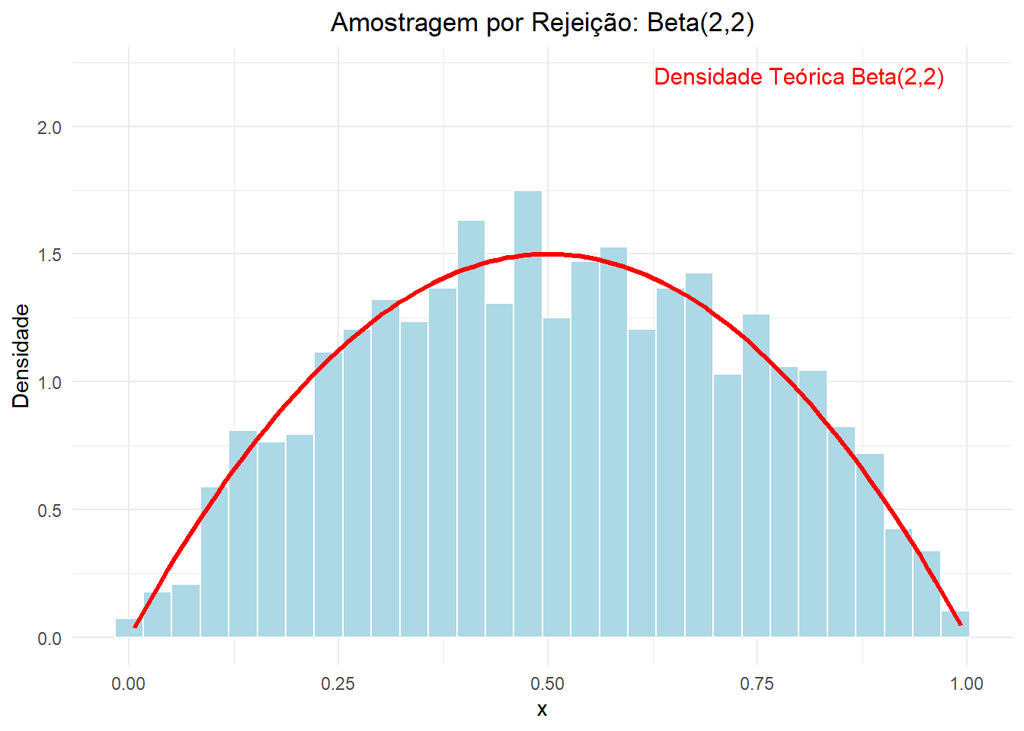

```r
# Crie um histograma das suas amostras geradas
# Sobreponha a curva de densidade teórica da Beta(2, 2) para verificar

# Organize as amostras em um data frame
df_beta <- data.frame(amostra = amostras_beta)

# Crie o histograma com ggplot2 e sobreponha a densidade teórica
ggplot(df_beta, aes(x = amostra)) +
  geom_histogram(aes(y = ..density..), bins = 30, fill = "lightblue", color = "white") +
  stat_function(fun = function(x) dbeta(x, 2, 2), color = "red", size = 1.2) +
  labs(title = "Amostragem por Rejeição: Beta(2,2)",
       x = "x", y = "Densidade") +
  theme_minimal() +
  theme(plot.title = element_text(hjust = 0.5)) +
  annotate("text", x = 0.8, y = 2.2, label = "Densidade Teórica Beta(2,2)", color = "red", size = 4)
```

```r
# Reporte a taxa de aceitação do seu amostrador

cat("Taxa de aceitação:", round(resultado_beta$taxa_aceitacao, 4), "\n")
```

```
Taxa de aceitação: 0.6761
```

```r
cat("Total de propostas:", resultado_beta$total_propostas, "\n")
```

```
Total de propostas: 2958
```

**Análise da Tarefa 2.3:**

## Problema 3: O Algoritmo de Metropolis-Hastings (Capítulo 9)

O objetivo é gerar amostras de uma distribuição Normal Bivariada com alta correlação ($\rho=0.9$) usando um amostrador de Metropolis-Hastings de passeio aleatório.

### 3.1 Implementando o Amostrador

```r
# Defina a densidade alvo (ou seu logaritmo)
# A média é (0, 0) e a matriz de covariância tem 1s na diagonal e 0.9 fora dela.
# A função `mvtnorm::dmvnorm` pode ser útil para calcular a densidade.

mu <- c(0, 0)
Sigma <- matrix(c(1, 0.9, 0.9, 1), nrow = 2)
log_alvo <- function(x) {
  mvtnorm::dmvnorm(x, mean = mu, sigma = Sigma, log = TRUE)
}

# Implemente a função do amostrador de Metropolis-Hastings
metropolis_bvn <- function(n_iter, sigma_prop) {
  # n_iter: número de iterações
  # sigma_prop: desvio padrão da proposta (assumido igual para ambas as dimensões)

  # 1. Inicializar a cadeia
  cadeia_mk <- matrix(0, nrow = n_iter, ncol = 2)
  estado_atual <- c(0, 0)  # Ponto inicial (0, 0)
  cadeia_mk[1, ] <- estado_atual

  # Contador de aceitações
  n_aceito <- 0

  # Matriz de covariância para a proposta (diagonal)
  Sigma_prop <- diag(c(sigma_prop^2, sigma_prop^2))

  # 2. Loop pelas iterações
  for (i in 2:n_iter) {

    # 3. Propor um novo ponto a partir da distribuição de proposta
    # Proposta Normal Bivariada centrada no ponto atual
    proposta <- rnorm(2, mean = estado_atual, sd = sigma_prop)
    proposta <- as.vector(proposta)

    # 4. Calcular a razão de aceitação
    # r = f(proposto) / f(atual)
    log_r <- log_alvo(proposta) - log_alvo(estado_atual)
    r <- exp(log_r)

    # 5. Aceitar o ponto proposto com probabilidade min(1, r)
    if (runif(1) < min(1, r)) {
      # Se rejeitado, o próximo ponto da cadeia é o mesmo que o ponto atual
      estado_atual <- proposta
      n_aceito <- n_aceito + 1
    }
    # Caso contrário, permanece no estado atual (estado_atual inalterado)

    # 6. Armazenar o ponto na cadeia
    cadeia_mk[i, ] <- estado_atual
  }

  # 7. Calcular taxa de aceitação
  tx_aceita <- n_aceito / (n_iter - 1)

  # Retornar resultados
  return(list(
    cadeia_mk = cadeia_mk,
    tx_aceita = tx_aceita,
    n_aceito = n_aceito,
    n_iter = n_iter
  ))
}

# Execute o amostrador
set.seed(123)
# Teste com diferentes valores de sigma_prop para ver o efeito na taxa de aceitação
resultado_mcmc <- metropolis_bvn(n_iter = 10000, sigma_prop = 1.0)
cadeia_mcmc <- resultado_mcmc$cadeia_mk
```

```r
result_mcmc_sigma05 <- metropolis_bvn(n_iter = 100000, sigma_prop = 0.5)

result_mcmc_sigma2 <- metropolis_bvn(n_iter = 10000, sigma_prop = 2)
```